# Odlin Montila

**Using pandas to read in the bank_note_data.csv file**

```python
import pandas as pd
```

```python
data = pd.read_csv('bank_note_data.csv')
```

**Checking the head of the Data**

```python
data.head()
```

|  | Image.Var | Image.Skew | Image.Curt | Entropy | Class |
| --- | --- | --- | --- | --- | --- |
| 0 | 3.62160 | 8.6661 | -2.8073 | -0.44699 | 0 |
| 1 | 4.54590 | 8.1674 | -2.4586 | -1.46210 | 0 |
| 2 | 3.86600 | -2.6383 | 1.9242 | 0.10645 | 0 |
| 3 | 3.45660 | 9.5228 | -4.0112 | -3.59440 | 0 |
| 4 | 0.32924 | -4.4552 | 4.5718 | -0.98880 | 0 |

**Importing seaborn and set matplolib inline for viewing**

```python
import seaborn as sns
%matplotlib inline
```

**Creating a Countplot of the Classes (Authentic 1 vs Fake 0)**

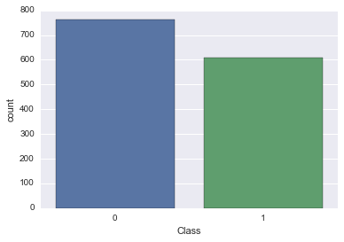

```python
sns.countplot(x='Class',data=data)
```

**Creating a PairPlot of the Data with Seaborn, setting Hue to Class**

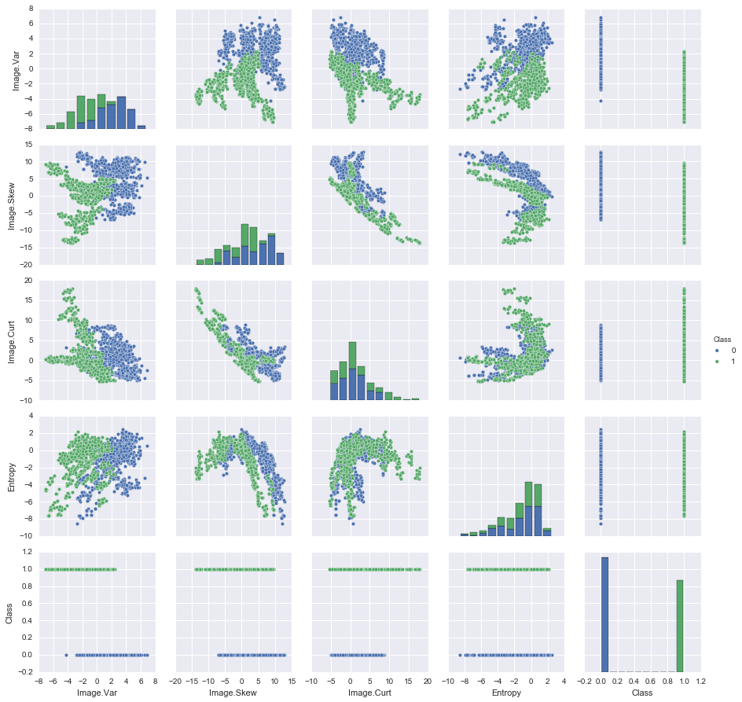

```python
sns.pairplot(data,hue='Class')
```

## Data Preparation

### Standard Scaling

```python
from sklearn.preprocessing import StandardScaler
```

**Creating a StandardScaler() object called scaler.**

```python
scaler = StandardScaler()
```

**Fitting scaler to the features.**

```python
scaler.fit(data.drop('Class',axis=1))
```

```
StandardScaler(copy=True, with_mean=True, with_std=True)
```

**Using the .transform() method to transform the features to a scaled version.**

```python
scaled_features = scaler.fit_transform(data.drop('Class',axis=1))
```

**Converting the scaled features to a dataframe and check the head of this dataframe to make sure the scaling worked.**

```python
df_feat = pd.DataFrame(scaled_features,columns=data.columns[:-1])
df_feat.head()
```

|  | Image.Var | Image.Skew | Image.Curt | Entropy |
| --- | --- | --- | --- | --- |
| 0 | 1.121806 | 1.149455 | -0.975970 | 0.354561 |
| 1 | 1.447066 | 1.064453 | -0.895036 | -0.128767 |
| 2 | 1.207810 | -0.777352 | 0.122218 | 0.618073 |
| 3 | 1.063742 | 1.295478 | -1.255397 | -1.144029 |
| 4 | -0.036772 | -1.087038 | 0.736730 | 0.096587 |

## Train Test Split

**Creating two objects X and y which are the scaled feature values and labels respectively.**

```python
X = df_feat
```

```python
y = data['Class']
```

```python
X = X.as_matrix()
y = y.as_matrix()
```

**Using SciKit Learn to create training and testing sets of the data**

```python
from sklearn.cross_validation import train_test_split
```

```python
X_train, X_test, y_train, y_test = train_test_split(X, y, test_size=0.3)
```

# Contrib.learn

**Import tensorflow.contrib.learn.python.learn as learn**

```python
import tensorflow.contrib.learn.python.learn as learn
```

**Creating an object called classifier which is a DNNClassifier from learn. Set it to have 2 classes and a [10,20,10] hidden unit layer structure:**

```python
classifier = learn.DNNClassifier(hidden_units=[10, 20, 10], n_classes=2)
```

**Now fit classifier to the training data. Use steps=200 with a batch_size of 20.**

*Note: I ignore any warnings i get, they won't effect the output*

```python
classifier.fit(X_train, y_train, steps=200, batch_size=20)
```

```
/Users/marci/anaconda/lib/python3.5/site-packages/tensorflow/python/ops/array_ops.py:1197: VisibleDeprecationWarning: converting an array with ndim > 0 to an index will result in an error in the future
  result_shape.insert(dim, 1)
```

```
DNNClassifier()
```

## Model Evaluation

**Using the predict method from the classifier model to create predictions from X_test**

```python
note_predictions = classifier.predict(X_test)
```

**Now i create a classification report and a Confusion Matrix.**

```python
from sklearn.metrics import classification_report,confusion_matrix
```

```python
print(confusion_matrix(y_test,note_predictions))
```

```
[[237   0]
 [  1 174]]
```

```python
print(classification_report(y_test,note_predictions))
```

```
             precision    recall  f1-score   support

          0       1.00      1.00      1.00       237
          1       1.00      0.99      1.00       175

avg / total       1.00      1.00      1.00       412
```